# 의학통계방법론 1조 10주차 과제

김재혁, 정지현

2022-05-12

```r
getwd()
```

```
## [1] "C:/git_blog/study/data/의학통계방법론/ch17"
```

```r
library("dplyr")
library("kableExtra")
library("ggplot2")
library("chemCal")
library("broom")
```

## 0.1 17장

### 0.1.1 EXAMPLE 17.1

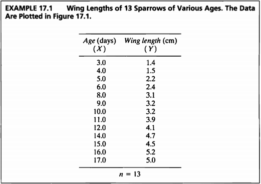

```r
#데이터셋
age <- c(3.0,4.0,5.0,6.0,8.0,9.0,10.0,11.0,12.0,14.0,15.0,16.0,17.0)
wing_length<-c(1.4,1.5,2.2,2.4,3.1,3.2,3.2,3.9,4.1,4.7,4.5,5.2,5.0)
ex17_1 <- data.frame(age,wing_length)
ex17_1 %>%
  kbl(caption = "Dataset of Example 17.1") %>%
  kable_styling(bootstrap_options = c("striped", "hover", "condensed", "responsive"))
```

Dataset of Example 17.1

| age | wing_length |
| --- | --- |
| 3 | 1.4 |
| 4 | 1.5 |
| 5 | 2.2 |
| 6 | 2.4 |
| 8 | 3.1 |
| 9 | 3.2 |
| 10 | 3.2 |
| 11 | 3.9 |
| 12 | 4.1 |
| 14 | 4.7 |
| 15 | 4.5 |
| 16 | 5.2 |
| 17 | 5.0 |

- 해당 데이터는 참새의 나이와 날개의 길이를 측정한 데이터이다.
- 이 데이터를 사용하여 연령과 날개 길이의 회귀직선을 그려보도록 한다.

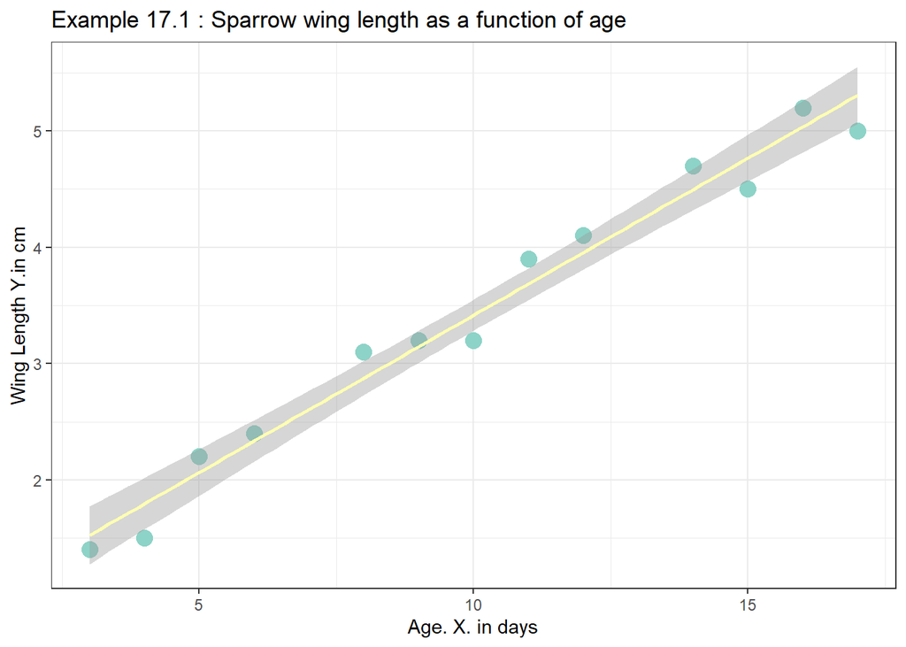

```r
library("ggplot2")
ggplot(ex17_1, aes(x=age, y=wing_length)) +
  geom_point(color="#8dd3c7",size=4) +
  stat_smooth(method = 'lm', color="#ffffb3")+
  ggtitle("Example 17.1 : Sparrow wing length as a function of age")+
  ylab("Wing Length Y.in cm")+
  xlab("Age. X. in days")+
  theme_bw()
```

### 0.1.2 EXAMPLE 17.2

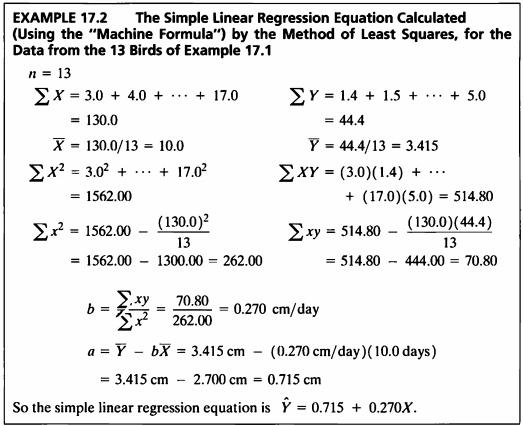

- EXAMPLE 17.1 데이터로 Machine formula를 사용하여 회귀식을 구하도록 한다.

```r
f_17_2 <- function(x){
  n <- nrow(x)
  sum_x <- sum(x[,1])
  mean_x <- mean(x[,1])
  sum_y <- sum(x[,2])
  mean_y <- mean(x[,2])
  sum_x2 <- sum(x[,1]^2)
  sum_xy <- sum(x[,1]*x[,2])
  b <- (sum_xy-((sum_x*sum_y)/n))/(sum_x2-(sum_x^2)/n)
  a <- mean_y - b*mean_x
  out <- data.frame(n,sum_x,mean_x,sum_y,mean_y,sum_x2,sum_xy,b,a)
  return(out)
}

f_17_2(ex17_1)%>%
  kbl(caption = "Result of simple linear regression equation",escape=F) %>%
  kable_styling(bootstrap_options = c("striped", "hover", "condensed", "responsive"))
```

Result of simple linear regression equation

| n | sum_x | mean_x | sum_y | mean_y | sum_x2 | sum_xy | b | a |
| --- | --- | --- | --- | --- | --- | --- | --- | --- |
| 13 | 130 | 10 | 44.4 | 3.415385 | 1562 | 514.8 | 0.270229 | 0.7130945 |

- 회귀식을 추정한 결과
  $$\hat Y =
  0.715+0.270X$$
  로 도출되었다.
- Example 17.1에서 구한 회귀직선에 식을 넣으면 다음과 같다.

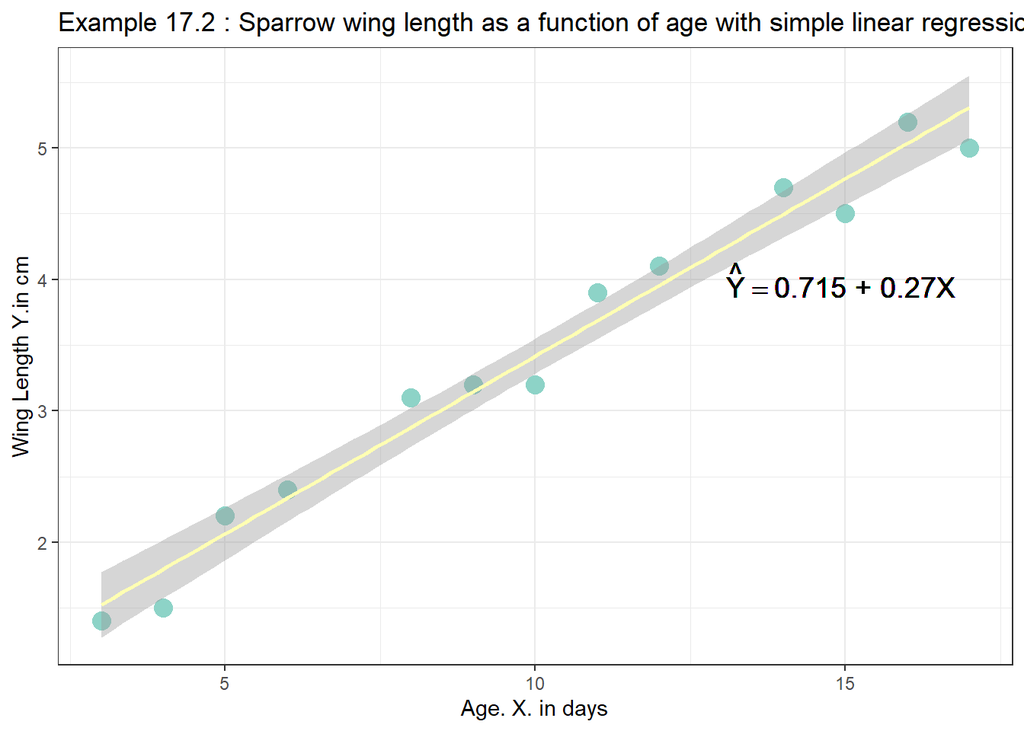

```r
ggplot(ex17_1, aes(x=age, y=wing_length)) +
  geom_point(color="#8dd3c7",size=4) +
  stat_smooth(method = 'lm', color="#ffffb3")+
  ggtitle("Example 17.2 : Sparrow wing length as a function of age with simple linear regression equation")+
  ylab("Wing Length Y.in cm")+
  xlab("Age. X. in days")+
  theme_bw()+
  geom_text(x=15, y=4, label=expression(hat(Y) == paste(0.715," + ",0.270,X, " ",)), cex = 5)
```

### 0.1.3 EXAMPLE 17.3

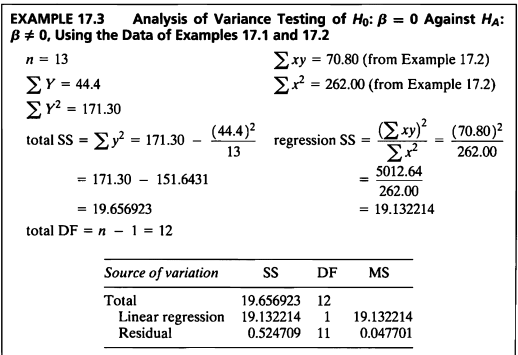

- 앞서 구한 회귀식의 ANOVA table을 작성하여 추정한 회귀식의 유의성을 판단하여 보겠다.

```r
library("broom")
lm17_2 <- lm(wing_length~age,data=ex17_1)
aov17_2 <- anova(lm17_2)
aov17_2 %>% tidy() %>%
  rename(" "="term","Sum Sq"="sumsq","Mean Sq"="meansq","F value"="statistic","Pr(>F)"="p.value") %>%
  kable(caption = "ANOVA table",booktabs = TRUE, valign = 't') %>%
  kable_styling(bootstrap_options = c("striped", "hover", "condensed", "responsive"))
```

ANOVA table

|  | df | Sum Sq | Mean Sq | F value | Pr(>F) |
| --- | --- | --- | --- | --- | --- |
| age | 1 | 19.1322137 | 19.1322137 | 401.0875 | 0 |
| Residuals | 11 | 0.5247093 | 0.0477008 | NA | NA |

```r
summ <- summary(lm17_2)
data.frame(summ$r.squared,summ$adj.r.squared) %>%
  rename("R square"="summ.r.squared","Adjusted R square"="summ.adj.r.squared") %>%
  kable(caption = "R square",booktabs = TRUE, valign = 't') %>%
  kable_styling(bootstrap_options = c("striped", "hover", "condensed", "responsive"))
```

R square

| R square | Adjusted R square |
| --- | --- |
| 0.9733066 | 0.97088 |

$$\begin{aligned}
H_0 &: Regression\ model\ is\ not\ significant \\
H_A &: Regression\ model\ is\ significant
\end{aligned}$$
- 회귀직선의 유의성을 판단한 결과, F값은 401.09, p-value<0.001 이므로
$$H_0:
\beta_1=0$$
은 기각되었다.
따라서 유의수준 5%하에 회귀직선은 유의하다고 할 수 있다.
- 결정계수 값은 0.97로, 총변동중에서 회귀직선에 의해 설명되는 부분이 97%임을 확인하였다.

### 0.1.4 EXAMPLE 17.4

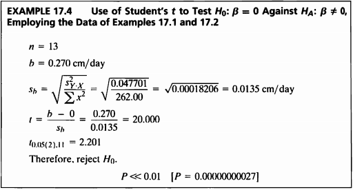

- EXAMPLE 1,2에 사용된 데이터를 가지고 회귀계수의 유의성 검정을 하기 위해 t-test를 진행해 보도록 하겠다.

> 직접 함수를를 작성하여 구하여 보겠다

```r
f_17_4 <- function(x){
  alpha <- 0.05
  n <- nrow(x)
  estimate <- f_17_2(x)$b
  r2 <- summ$r.squared
  syx2 <- (sd(x[,2])*sqrt((1-r2)*(13-1)/(13-2)))^2
  sum_x2 <- sum(x[,1]^2)-(sum(x[,1])^2)/n
  se <- sqrt(syx2/sum_x2)
  t <- estimate/se
  crit <- qt(1-alpha/2,n-2)
  pvalue <- pt(t,n-2,lower.tail = F)
  if(pvalue < 0.05){
    Reject_H0 <- "yes"
  }else{
    Reject_H0 <- "No"
  }
  out <- data.frame(n,estimate,se,t,pvalue,Reject_H0)
  return(out)
}

f_17_4(ex17_1)%>%
  kbl(caption = "Result of t test",escape=F) %>%
  kable_styling(bootstrap_options = c("striped", "hover", "condensed", "responsive"))
```

Result of t test

| n | estimate | se | t | pvalue | Reject_H0 |
| --- | --- | --- | --- | --- | --- |
| 13 | 0.270229 | 0.0134931 | 20.02717 | 0 | yes |

> R에 내장된 함수로 구하여 보겠다

```r
summ$coefficients %>%
  as.data.frame() %>%
  kable(caption = "Coefficient",booktabs = TRUE, valign = 't') %>%
  kable_styling(bootstrap_options = c("striped", "hover", "condensed", "responsive"))
```

Coefficient

|  | Estimate | Std. Error | t value | Pr(>\|t\|) |
| --- | --- | --- | --- | --- |
| (Intercept) | 0.7130945 | 0.1479045 | 4.821319 | 0.0005347 |
| age | 0.2702290 | 0.0134931 | 20.027169 | 0.0000000 |

- 본 검정의 가설은 다음과 같다.

$$\begin{aligned}
H_0 &: \beta=0 \\
H_A &: \beta \ne 0
\end{aligned}$$

- 회귀계수의 유의성 검정 결과 age에 대한 coefficient 값은 0.2702290, t 값은 20.02 이며 p-value<0.001 로써 유의수준 0.05보다 작아 귀무가설을 기각할 충분한 근거를 가진다.  
  -그러므로 유의수준 5%하에 회귀계수는 유의하다고 할 수 있다.

### 0.1.5 EXAMPLE 17.5

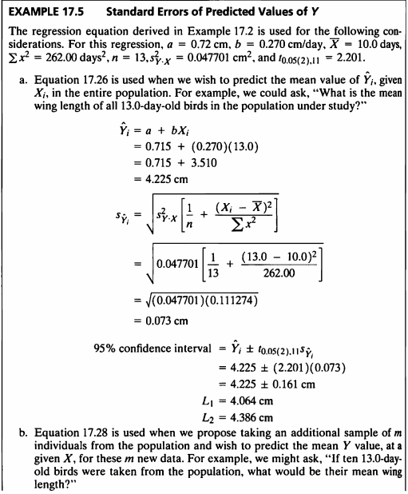

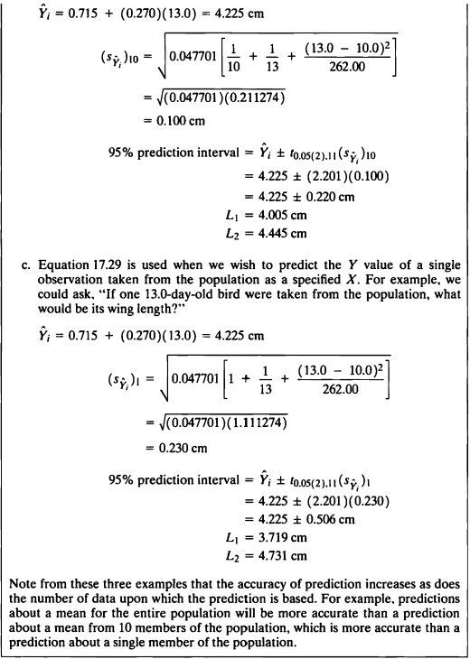

- 다음의 식을 통하여 표준오차를 구해해 신뢰구간을 예측해보도록 하겠겠다.

- 13 day old의 새들의 날개의 길이의 모평균은 얼마인지 표준오차를 구해 신뢰구간을 계산해보도록 하겠다.

```r
f_17_5 <- function(x,param){
  alpha <- 0.05
  n <- nrow(x)
  b <- f_17_2(x)$b
  a <- f_17_2(x)$a
  yi <- a+b*param
  r2 <- summ$r.squared
  mean_x <- mean(x[,1])
  syx2 <- (sd(x[,2])*sqrt((1-r2)*(13-1)/(13-2)))^2
  sum_x <- sum(x[,1])
  sum_x2 <- sum(x[,1]^2)
  sumx2 <- sum_x2-(sum_x^2)/n
  syi <- sqrt(syx2*((1/param)+((param-mean_x)^2/(sum_x2-(sum_x^2)/n))))
  syi_10 <- sqrt(syx2*((1/10)+(1/param)+((param-mean_x)^2/(sum_x2-(sum_x^2)/n))))
  syi_1 <- sqrt(syx2*(1+(1/param)+((param-mean_x)^2/(sum_x2-(sum_x^2)/n))))
  crit <- qt(1-alpha/2,n-2)
  L1_1 <- yi-crit*syi
  L2_1 <- yi+crit*syi
  L1_2 <- yi-crit*syi_10
  L2_2 <- yi+crit*syi_10
  L1_3 <- yi-crit*syi_1
  L2_3 <- yi+crit*syi_1
  out <- data.frame(yi,syi,L1_1,L2_1,syi_10,L1_2,L2_2,syi_1,L1_3,L2_3)
  return(out)
}

f_17_5(ex17_1,13)%>%
  kbl(caption = "Result",escape=F) %>%
  kable_styling(bootstrap_options = c("striped", "hover", "condensed", "responsive"))
```

Result

| yi | syi | L1_1 | L2_1 | syi_10 | L1_2 | L2_2 | syi_1 | L1_3 | L2_3 |
| --- | --- | --- | --- | --- | --- | --- | --- | --- | --- |
| 4.226072 | 0.0728552 | 4.065719 | 4.386425 | 0.100389 | 4.005117 | 4.447026 | 0.2302362 | 3.719325 | 4.732818 |

### 0.1.6 EXAMPLE 17.6

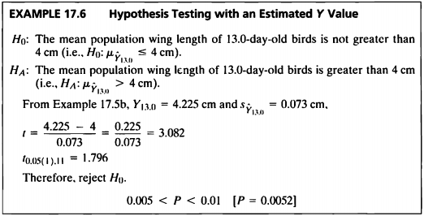

- Estimated Y Value에 대하여 검정을 진행하여 보겠겠다.

$$\begin{aligned}
H_0 &: The \ mean \ population \ wing \ length \ of \ 13.0-day-birds
\ is \ not \ greater \ than \ 4cm \\
H_A &: The \ mean \ population \ wing \ length \ of \ 13.0-day-birds
\ is \ greater \ than \ 4cm
\end{aligned}$$

```r
f_17_6 <- function(x,param,compare){
  alpha <- 0.05
  n <- nrow(x)
  b <- f_17_2(x)$b
  a <- f_17_2(x)$a
  yi <- a+b*param
  r2 <- summ$r.squared
  mean_x <- mean(x[,1])
  syx2 <- (sd(x[,2])*sqrt((1-r2)*(13-1)/(13-2)))^2
  sum_x <- sum(x[,1])
  sum_x2 <- sum(x[,1]^2)
  sumx2 <- sum_x2-(sum_x^2)/n
  syi <- sqrt(syx2*((1/param)+((param-mean_x)^2/(sum_x2-(sum_x^2)/n))))
  t <- (yi-compare)/syi
  crit <- qt(1-alpha/2,n-2)
  pvalue <- pt(t,n-2,lower.tail = F)
  if(pvalue < 0.05){
    Reject_H0 <- "yes"
  }else{
    Reject_H0 <- "No"
  }
  out <- data.frame(yi,t,crit,pvalue,Reject_H0)
  return(out)
}

f_17_6(ex17_1,param=13,compare=4)%>%
  kbl(caption = "Result",escape=F) %>%
  kable_styling(bootstrap_options = c("striped", "hover", "condensed", "responsive"))
```

Result

| yi | t | crit | pvalue | Reject_H0 |
| --- | --- | --- | --- | --- |
| 4.226072 | 3.103028 | 2.200985 | 0.0050248 | yes |

- 예측된 Y값 검정 결과 검정통계량 t값은 3.10이고 p-value=0.005 이므므로 유의수준 0.05보다 작아 귀무가설을 기각할 충분한 근거가 있다.
- 그러므로 유의수준5%하에 새들의 날개의 길이에 대한 모평균이 4cm 보다 크다는 충분한 근거가 있다고 할 수 있다.

### 0.1.7 EXAMPLE 17.7

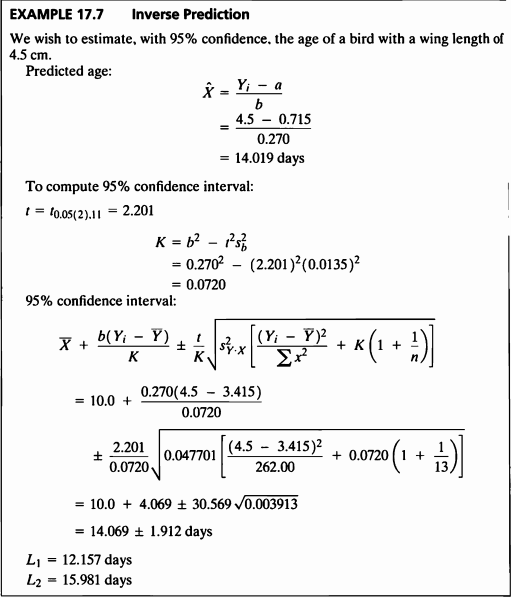

- 이번에는 y값이 주어졌을 때 x값을 구해보도록 하겠다.
- 즉, 날개의 길이가 주어졌을 때, 새들의 나이를 예측해보는 inverse에 관한 문제이다.
- 날개의 길이가 4.5cm 라고 했을 때 신뢰구간을 구하는 방식은 다음과 같다.

$$\begin{aligned}
&\overline X + \frac{b(Y_i - \overline Y)}{K} \pm
\frac{t}{K}\sqrt{(s^2_{Y*X})'[\frac{(Y_i-\overline Y)^2}{\sum
x^2}+K(\frac{1}{m}+\frac{1}{n})]}\\ \\
&where\ \ t=t_{\alpha(2),(n+m-3)}, \ \ \ K=b^2-t^2(s_b^2)'\\ \\
&(s_b^2)'=\frac{(s_{Y*X}^2)'}{\sum x^2}, \ \ \ \
\ (s_{Y*X}^2)'=residual\ SS+\sum_{j=1}^m (Y_{ij}-\overline
Y_i)^2/(n+m-3)
\end{aligned}$$

> R의 chemCal 패키지의 inverse.predict() 함수를 사용하여 구해보겠다

```r
library("chemCal")
inverse_result <- inverse.predict(lm17_2,4.5)
inverse_result <- as.data.frame(inverse_result)
inverse_result[2,1:3] <- "."
inverse_result %>%
  kbl(caption = "Result of Inverse Prediction",escape=F) %>%
  kable_styling(bootstrap_options = c("striped", "hover", "condensed", "responsive"))
```

Result of Inverse Prediction

| Prediction | Standard.Error | Confidence | Confidence.Limits |
| --- | --- | --- | --- |
| 14.0136897001304 | 0.862343975232319 | 1.89800629238076 | 12.11568 |
| . | . | . | 15.91170 |

- 위의 결과를 보아 날개의 길이가 4.5cm라고 주어졌을 때  
  예상되는 새의 나이의 값은 14.013이고  
  이에 대한 95% 신뢰구간은 [12.115, 15.911] 이다.

### 0.1.8 EXAMPLE 17.8a

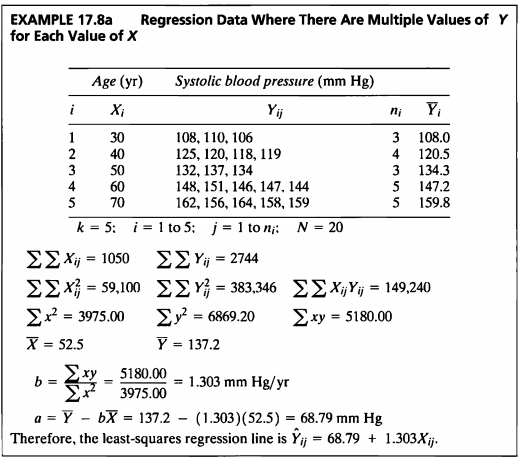

```r
#데이터셋
age<-c(rep(30,3),rep(40,4),rep(50,3),rep(60,5),rep(70,5))
sbp<-c(108,110,106,125,120,118,119,132,137,134,148,151,146,147,144,162,156,164,158,159)
ex17_8 <- data.frame(age,sbp)
ex17_8 %>%
  kbl(caption = "Dataset of Example 17_8a",escape=F) %>%
  kable_styling(bootstrap_options = c("striped", "hover", "condensed", "responsive"))
```

Dataset of Example 17_8a

| age | sbp |
| --- | --- |
| 30 | 108 |
| 30 | 110 |
| 30 | 106 |
| 40 | 125 |
| 40 | 120 |
| 40 | 118 |
| 40 | 119 |
| 50 | 132 |
| 50 | 137 |
| 50 | 134 |
| 60 | 148 |
| 60 | 151 |
| 60 | 146 |
| 60 | 147 |
| 60 | 144 |
| 70 | 162 |
| 70 | 156 |
| 70 | 164 |
| 70 | 158 |
| 70 | 159 |

- 해당 데이터는 나이와 이에 따른 수축기혈압의 데이터이다.
- 각각의 x에 대해 multiple value Y를 가지는 회귀분석에 대한 문제이다.

> 모형의 유의성 검정

$$\begin{aligned}
H_0 &: Regression\ model\ is\ not\ significant \\
H_A &: Regression\ model\ is\ significant
\end{aligned}$$

```r
lm17_8 <- lm(sbp~age,data=ex17_8)
aov17_8 <- anova(lm17_8)
aov17_8%>% tidy() %>%
  rename(" "="term","Sum Sq"="sumsq","Mean Sq"="meansq","F value"="statistic","Pr(>F)"="p.value") %>%
  kable(caption = "ANOVA table",booktabs = TRUE, valign = 't') %>%
  kable_styling(bootstrap_options = c("striped", "hover", "condensed", "responsive"))
```

ANOVA table

|  | df | Sum Sq | Mean Sq | F value | Pr(>F) |
| --- | --- | --- | --- | --- | --- |
| age | 1 | 6750.2893 | 6750.289308 | 1021.819 | 0 |
| Residuals | 18 | 118.9107 | 6.606149 | NA | NA |

- 모형의 유의성 검정 결과 검정통계량 F값은 1021.819, p-value<0.001이므로 유의수준 0.05보다 작아 귀무가설을 기각할 충분한 근거를 가진다.
- 그러므로 유의수준 5%하에 회귀모형은 유의하다고 할 수 있다. > 회귀계수의 유의성 검정

$$\begin{aligned}
H_0 &: \beta=0 \\
H_A &: \beta \ne 0
\end{aligned}$$

```r
summary(lm17_8)[4] %>%
  as.data.frame %>%
  rename("Estimate"="coefficients.Estimate","Standard Error"="coefficients.Std..Error","t value"="coefficients.t.value","Pr(>F)"="coefficients.Pr...t..") %>%
  kable(caption = "Test of Coefficients",booktabs = TRUE, valign = 't') %>%
  kable_styling(bootstrap_options = c("striped", "hover", "condensed", "responsive"))
```

Test of Coefficients

|  | Estimate | Standard Error | t value | Pr(>F) |
| --- | --- | --- | --- | --- |
| (Intercept) | 68.784906 | 2.2160746 | 31.03907 | 0 |
| age | 1.303145 | 0.0407667 | 31.96590 | 0 |

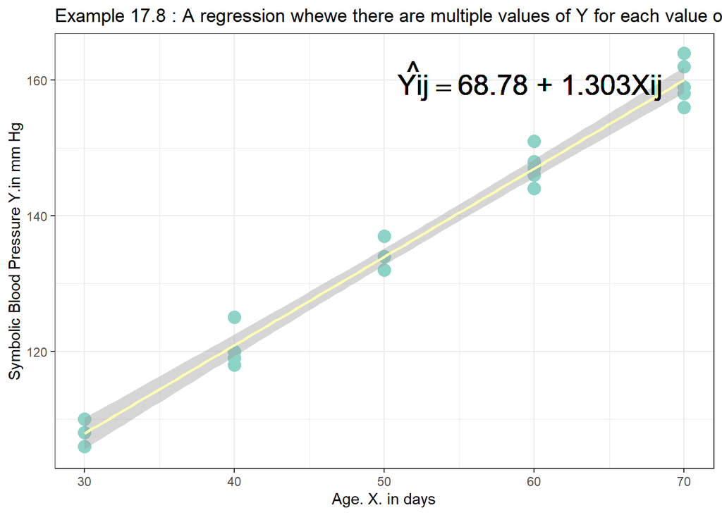

```r
ggplot(ex17_8, aes(x=age, y=sbp)) +
  geom_point(color="#8dd3c7",size=4) +
  stat_smooth(method = 'lm', color="#ffffb3")+
  ggtitle("Example 17.8 : A regression whewe there are multiple values of Y for each value of X")+
  ylab("Symbolic Blood Pressure Y.in mm Hg")+
  xlab("Age. X. in days")+
  theme_bw()+
  geom_text(x=60, y=160, label=expression(hat(Yij) == paste(68.78," + ",1.303,Xij, " ",)), cex = 7)
```

### 0.1.9 EXAMPLE 17.8b

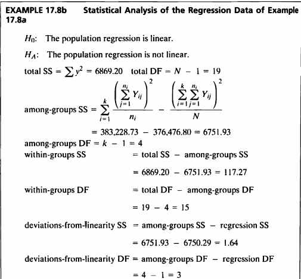

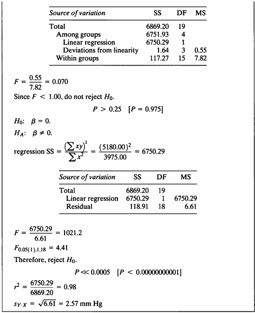

- EXAMPLE 17.8a에서 구한 회귀모형의 선형성 검정을 위해 적합결여 F-test 를 수행하도록 하겠다.
- 선형성 검정을 하기 위해서는 단순 선형모형을 고려한 축소모형과 설명변수 각각의 값들을 factor화 하여 적합한 모형인 전체모형을 구한 뒤 Reduced model과 Full model 사이의 분산분석을 통하여 선형성을 검정한다.

> Reduced model

```r
rm <- lm(sbp~age,data=ex17_8)
summary(rm) %>% tidy %>%
  rename("t value"="statistic","P value"="p.value") %>%
  kable(caption = "Reduced model",booktabs = TRUE, valign = 't') %>%
  kable_styling(bootstrap_options = c("striped", "hover", "condensed", "responsive"))
```

Reduced model

| term | estimate | std.error | t value | P value |
| --- | --- | --- | --- | --- |
| (Intercept) | 68.784906 | 2.2160746 | 31.03907 | 0 |
| age | 1.303145 | 0.0407667 | 31.96590 | 0 |

> Full model

```r
fm <- lm(sbp~factor(age),data=ex17_8)
summary(fm) %>% tidy %>%
  rename("t value"="statistic","P value"="p.value") %>%
  kable(caption = "Reduced model",booktabs = TRUE, valign = 't') %>%
  kable_styling(bootstrap_options = c("striped", "hover", "condensed", "responsive"))
```

| term | estimate | std.error | t value | P value |
| --- | --- | --- | --- | --- |
| (Intercept) | 108.00000 | 1.614288 | 66.902558 | 0.00e+00 |
| factor(age)40 | 12.50000 | 2.135502 | 5.853424 | 3.17e-05 |
| factor(age)50 | 26.33333 | 2.282948 | 11.534793 | 0.00e+00 |
| factor(age)60 | 39.20000 | 2.041931 | 19.197516 | 0.00e+00 |
| factor(age)70 | 51.80000 | 2.041931 | 25.368146 | 0.00e+00 |

> 선형성 검정 (Lack-of-fit test)

$$\begin{aligned}
H_0 &: The \ population \ regression \ is \ linear. \\
H_A &: The \ population \ regression \ is \ not \ linear.
\end{aligned}$$

```r
lof <- anova(rm,fm)
lof %>% tidy %>%
  rename("Res df"="df.residual","RSS"="rss","Sum sq"="sumsq","F value"="statistic","P value"="p.value") %>%
  kable(caption = "Reduced model",booktabs = TRUE, valign = 't') %>%
  kable_styling(bootstrap_options = c("striped", "hover", "condensed", "responsive"))
```

| term | Res df | RSS | df | Sum sq | F value | P value |
| --- | --- | --- | --- | --- | --- | --- |
| sbp ~ age | 18 | 118.9107 | NA | NA | NA | NA |
| sbp ~ factor(age) | 15 | 117.2667 | 3 | 1.644025 | 0.0700977 | 0.9750327 |

- 적합결여 검정 결과 검정통계량 F값은 0.07, p-value=0.975 이므로 유의수준 0.05보다 커 귀무가설을 기각할 충분한 근거를 가지고있지 않다.
- 그러므로 유의수준 5%하에 모 회귀모델은 선형성을 따른다고 할 충분한 근거가 있다고 할 수 있다다.

### 0.1.10 EXAMPLE 17.9

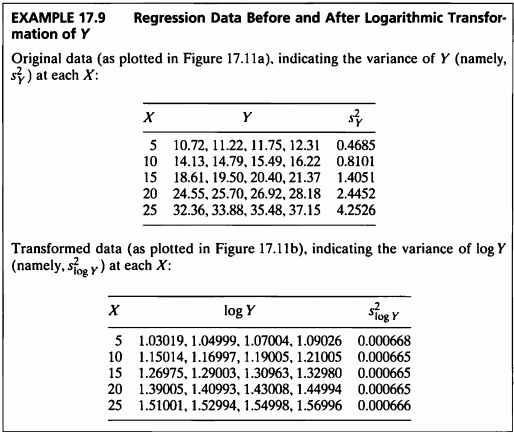

```r
#데이터셋
X<-c(rep(5,4),rep(10,4),rep(15,4),rep(20,4),rep(25,4))
Y<-c(10.72,11.22,11.75,12.31,14.13,14.79,15.49,16.22,18.61,19.50,20.40,21.37, 24.55,25.70,26.92,28.18,32.36,33.88,35.48,37.15)

ex17_9 <- data.frame(X,Y)
ex17_9%>%
  kbl(caption = "Dataset of Example 17_9",escape=F) %>%
  kable_styling(bootstrap_options = c("striped", "hover", "condensed", "responsive"))
```

Dataset of Example 17_9

| X | Y |
| --- | --- |
| 5 | 10.72 |
| 5 | 11.22 |
| 5 | 11.75 |
| 5 | 12.31 |
| 10 | 14.13 |
| 10 | 14.79 |
| 10 | 15.49 |
| 10 | 16.22 |
| 15 | 18.61 |
| 15 | 19.50 |
| 15 | 20.40 |
| 15 | 21.37 |
| 20 | 24.55 |
| 20 | 25.70 |
| 20 | 26.92 |
| 20 | 28.18 |
| 25 | 32.36 |
| 25 | 33.88 |
| 25 | 35.48 |
| 25 | 37.15 |

- 원 데이터와 로그변환한 데이터 간의 차이를 확인해보도록 하겠다.

> 로그변환

```r
log_y <- log(Y,base=10)
ex17_9_trans <- data.frame(X,log_y)
ex17_9_trans%>%
  kbl(caption = "Logarithmic transformation Dataset of Example 17_9",escape=F) %>%
  kable_styling(bootstrap_options = c("striped", "hover", "condensed", "responsive"))
```

Logarithmic transformation Dataset of Example 17_9

| X | log_y |
| --- | --- |
| 5 | 1.030195 |
| 5 | 1.049993 |
| 5 | 1.070038 |
| 5 | 1.090258 |
| 10 | 1.150142 |
| 10 | 1.169968 |
| 10 | 1.190051 |
| 10 | 1.210051 |
| 15 | 1.269746 |
| 15 | 1.290035 |
| 15 | 1.309630 |
| 15 | 1.329805 |
| 20 | 1.390051 |
| 20 | 1.409933 |
| 20 | 1.430075 |
| 20 | 1.449941 |
| 25 | 1.510009 |
| 25 | 1.529943 |
| 25 | 1.549984 |
| 25 | 1.569959 |

```r
ex17_9_result1 <- lm(Y~X, data=ex17_9)
#ex17.9_result1$residuals
ex17_9_result2 <- lm(log_y~X, data=ex17_9_trans)
#ex17.9_result2$residuals
```

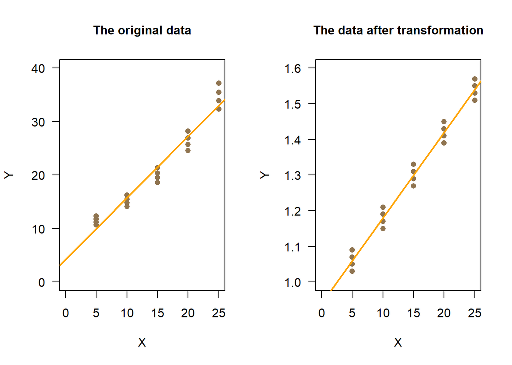

```r
par(mfrow=c(1,2))
plot(X, Y, pch=16,las=1,xlab="X", ylab="Y",ylim=c(0,40),xlim=c(0,25), main="The original data", cex.main=1, col="#8f7450")
abline(coef(ex17_9_result1), lwd=2, col="orange")
plot(X,log_y,pch=16,las=1,xlab="X",ylab="Y",ylim=c(1.0,1.6),xlim=c(0,25), main="The data after transformation", cex.main=1, col="#8f7450")
abline(coef(ex17_9_result2), lwd=2, col="orange")
```

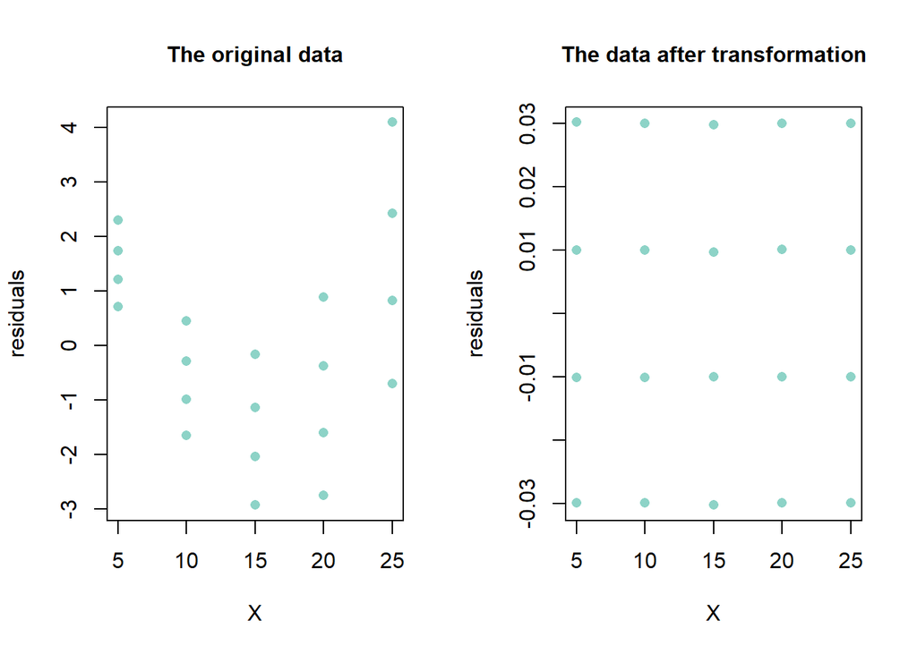

```r
par(mfrow=c(1,2))
plot(X, ex17_9_result1$residuals, xlab="X", ylab="residuals", main = "The original data", cex.main=1, pch=16, col="#8dd3c7")
plot(X, ex17_9_result2$residuals, xlab="X", ylab="residuals", main = "The data after transformation", cex.main=1, pch=16, col="#8dd3c7")
```

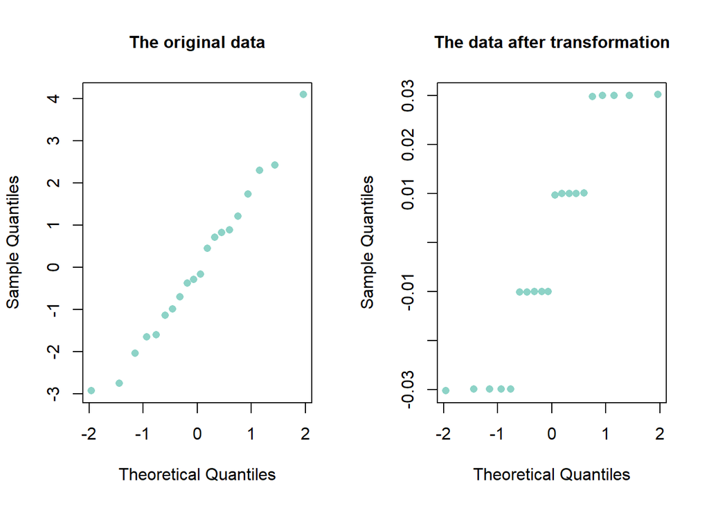

```r
par(mfrow=c(1,2))
qqnorm(ex17_9_result1$residuals, main = "The original data", cex.main=1, pch=16, col="#8dd3c7")
qqnorm(ex17_9_result2$residuals, main = "The data after transformation", cex.main=1, pch=16, col="#8dd3c7")
```

- 데이터를 로그변환하였을 때 더 강한 선형성을 가짐을 알 수 있다.
- 그리고 로그변환하였을 때의 잔차의 절대값이 변환 전보다 크게 줄었음을 알 수 있다.

```r
origin <- c(var(Y[ex17_9$X==5]),var(Y[ex17_9$X==10]),var(Y[ex17_9$X==15]),var(Y[ex17_9$X==20]),var(Y[ex17_9$X==25]))
logtrans <- c(var(log_y[ex17_9_trans$X==5]),var(log_y[ex17_9_trans$X==10]),var(log_y[ex17_9_trans$X==15]),var(log_y[ex17_9_trans$X==20]),var(log_y[ex17_9_trans$X==25]))
variance <- data.frame(origin,logtrans)
variance%>%
  kbl(caption = "Variance of each of original data set Logarithmic transformation",escape=F) %>%
  kable_styling(bootstrap_options = c("striped", "hover", "condensed", "responsive"))
```

Variance of each of original data set Logarithmic transformation

| origin | logtrans |
| --- | --- |
| 0.4684667 | 0.0006682 |
| 0.8100917 | 0.0006654 |
| 1.4051333 | 0.0006652 |
| 2.4452250 | 0.0006654 |
| 4.2525583 | 0.0006659 |